# W3cubDocs

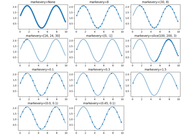

[Markevery Demo](https://matplotlib.org/3.5.1/gallery/lines_bars_and_markers/markevery_demo.html#sphx-glr-gallery-lines-bars-and-markers-markevery-demo-py)

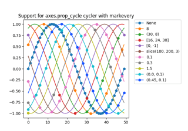

[prop_cycle property markevery in rcParams](https://matplotlib.org/3.5.1/gallery/lines_bars_and_markers/markevery_prop_cycle.html#sphx-glr-gallery-lines-bars-and-markers-markevery-prop-cycle-py)

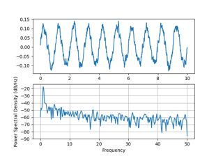

[Psd Demo](https://matplotlib.org/3.5.1/gallery/lines_bars_and_markers/psd_demo.html#sphx-glr-gallery-lines-bars-and-markers-psd-demo-py)

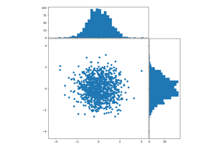

[Scatter plot with histograms](https://matplotlib.org/3.5.1/gallery/lines_bars_and_markers/scatter_hist.html#sphx-glr-gallery-lines-bars-and-markers-scatter-hist-py)

[figure not shown]

[Barcode](https://matplotlib.org/3.5.1/gallery/images_contours_and_fields/barcode_demo.html#sphx-glr-gallery-images-contours-and-fields-barcode-demo-py)

[figure not shown]

[Figimage Demo](https://matplotlib.org/3.5.1/gallery/images_contours_and_fields/figimage_demo.html#sphx-glr-gallery-images-contours-and-fields-figimage-demo-py)

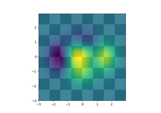

[Layer Images](https://matplotlib.org/3.5.1/gallery/images_contours_and_fields/layer_images.html#sphx-glr-gallery-images-contours-and-fields-layer-images-py)

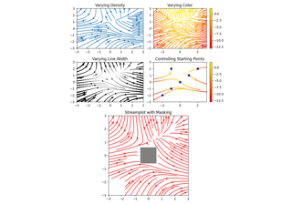

[Streamplot](https://matplotlib.org/3.5.1/gallery/images_contours_and_fields/plot_streamplot.html#sphx-glr-gallery-images-contours-and-fields-plot-streamplot-py)

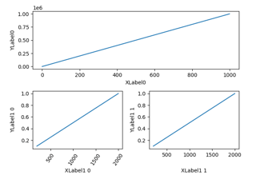

[Aligning Labels](https://matplotlib.org/3.5.1/gallery/subplots_axes_and_figures/align_labels_demo.html#sphx-glr-gallery-subplots-axes-and-figures-align-labels-demo-py)

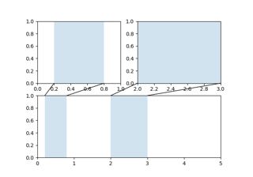

[Axes Zoom Effect](https://matplotlib.org/3.5.1/gallery/subplots_axes_and_figures/axes_zoom_effect.html#sphx-glr-gallery-subplots-axes-and-figures-axes-zoom-effect-py)

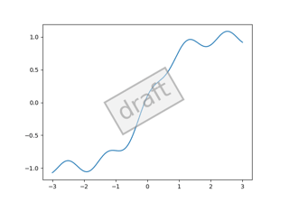

[Custom Figure subclasses](https://matplotlib.org/3.5.1/gallery/subplots_axes_and_figures/custom_figure_class.html#sphx-glr-gallery-subplots-axes-and-figures-custom-figure-class-py)

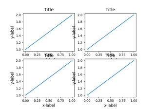

[Resizing axes with constrained layout](https://matplotlib.org/3.5.1/gallery/subplots_axes_and_figures/demo_constrained_layout.html#sphx-glr-gallery-subplots-axes-and-figures-demo-constrained-layout-py)

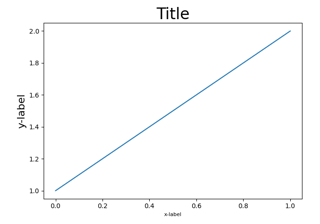

[Resizing axes with tight layout](https://matplotlib.org/3.5.1/gallery/subplots_axes_and_figures/demo_tight_layout.html#sphx-glr-gallery-subplots-axes-and-figures-demo-tight-layout-py)

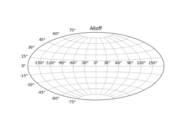

[Geographic Projections](https://matplotlib.org/3.5.1/gallery/subplots_axes_and_figures/geo_demo.html#sphx-glr-gallery-subplots-axes-and-figures-geo-demo-py)

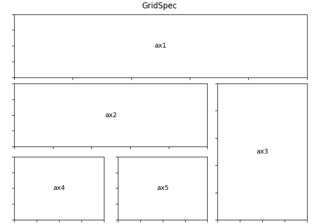

[Using Gridspec to make multi-column/row subplot layouts](https://matplotlib.org/3.5.1/gallery/subplots_axes_and_figures/gridspec_multicolumn.html#sphx-glr-gallery-subplots-axes-and-figures-gridspec-multicolumn-py)

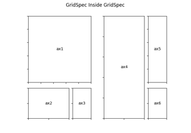

[Nested Gridspecs](https://matplotlib.org/3.5.1/gallery/subplots_axes_and_figures/gridspec_nested.html#sphx-glr-gallery-subplots-axes-and-figures-gridspec-nested-py)

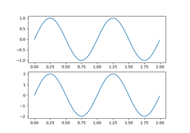

[Managing multiple figures in pyplot](https://matplotlib.org/3.5.1/gallery/subplots_axes_and_figures/multiple_figs_demo.html#sphx-glr-gallery-subplots-axes-and-figures-multiple-figs-demo-py)

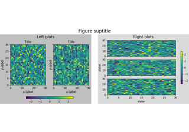

[Figure subfigures](https://matplotlib.org/3.5.1/gallery/subplots_axes_and_figures/subfigures.html#sphx-glr-gallery-subplots-axes-and-figures-subfigures-py)

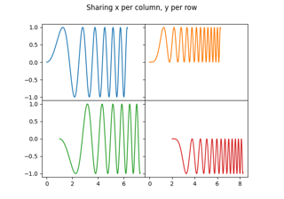

[Creating multiple subplots using plt.subplots](https://matplotlib.org/3.5.1/gallery/subplots_axes_and_figures/subplots_demo.html#sphx-glr-gallery-subplots-axes-and-figures-subplots-demo-py)

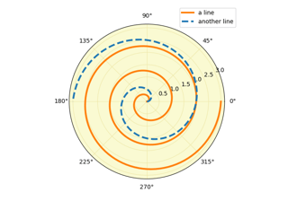

[Polar Legend](https://matplotlib.org/3.5.1/gallery/pie_and_polar_charts/polar_legend.html#sphx-glr-gallery-pie-and-polar-charts-polar-legend-py)

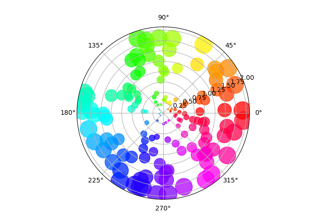

[Scatter plot on polar axis](https://matplotlib.org/3.5.1/gallery/pie_and_polar_charts/polar_scatter.html#sphx-glr-gallery-pie-and-polar-charts-polar-scatter-py)

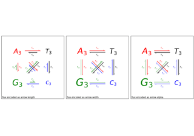

[Arrow Demo](https://matplotlib.org/3.5.1/gallery/text_labels_and_annotations/arrow_demo.html#sphx-glr-gallery-text-labels-and-annotations-arrow-demo-py)

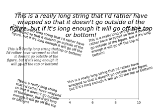

[Auto-wrapping text](https://matplotlib.org/3.5.1/gallery/text_labels_and_annotations/autowrap.html#sphx-glr-gallery-text-labels-and-annotations-autowrap-py)

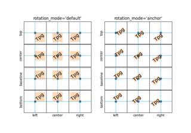

[Text Rotation Mode](https://matplotlib.org/3.5.1/gallery/text_labels_and_annotations/demo_text_rotation_mode.html#sphx-glr-gallery-text-labels-and-annotations-demo-text-rotation-mode-py)

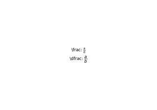

[The difference between \dfrac and \frac](https://matplotlib.org/3.5.1/gallery/text_labels_and_annotations/dfrac_demo.html#sphx-glr-gallery-text-labels-and-annotations-dfrac-demo-py)

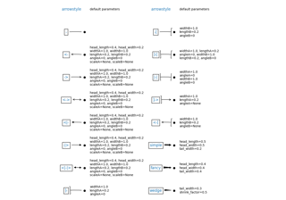

[Annotation arrow style reference](https://matplotlib.org/3.5.1/gallery/text_labels_and_annotations/fancyarrow_demo.html#sphx-glr-gallery-text-labels-and-annotations-fancyarrow-demo-py)

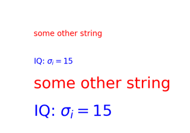

[Convert texts to images](https://matplotlib.org/3.5.1/gallery/text_labels_and_annotations/mathtext_asarray.html#sphx-glr-gallery-text-labels-and-annotations-mathtext-asarray-py)

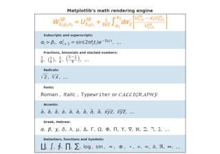

[Mathtext Examples](https://matplotlib.org/3.5.1/gallery/text_labels_and_annotations/mathtext_examples.html#sphx-glr-gallery-text-labels-and-annotations-mathtext-examples-py)

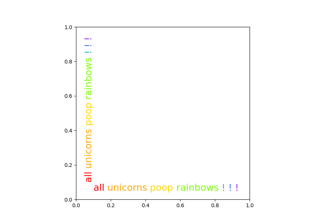

[Rainbow text](https://matplotlib.org/3.5.1/gallery/text_labels_and_annotations/rainbow_text.html#sphx-glr-gallery-text-labels-and-annotations-rainbow-text-py)

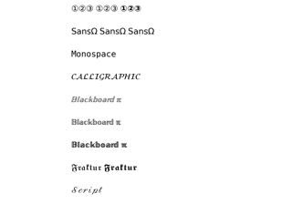

[STIX Fonts](https://matplotlib.org/3.5.1/gallery/text_labels_and_annotations/stix_fonts_demo.html#sphx-glr-gallery-text-labels-and-annotations-stix-fonts-demo-py)

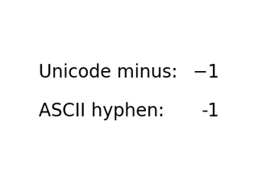

[Unicode minus](https://matplotlib.org/3.5.1/gallery/text_labels_and_annotations/unicode_minus.html#sphx-glr-gallery-text-labels-and-annotations-unicode-minus-py)

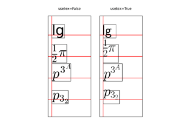

[Usetex Baseline Test](https://matplotlib.org/3.5.1/gallery/text_labels_and_annotations/usetex_baseline_test.html#sphx-glr-gallery-text-labels-and-annotations-usetex-baseline-test-py)

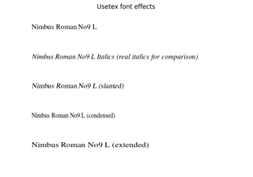

[Usetex Fonteffects](https://matplotlib.org/3.5.1/gallery/text_labels_and_annotations/usetex_fonteffects.html#sphx-glr-gallery-text-labels-and-annotations-usetex-fonteffects-py)

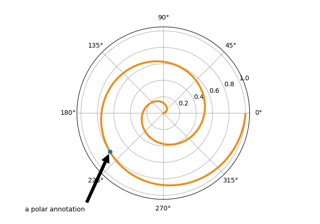

[Annotation Polar](https://matplotlib.org/3.5.1/gallery/pyplots/annotation_polar.html#sphx-glr-gallery-pyplots-annotation-polar-py)

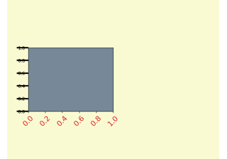

[Fig Axes Customize Simple](https://matplotlib.org/3.5.1/gallery/pyplots/fig_axes_customize_simple.html#sphx-glr-gallery-pyplots-fig-axes-customize-simple-py)

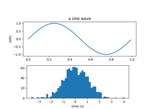

[Simple axes labels](https://matplotlib.org/3.5.1/gallery/pyplots/fig_axes_labels_simple.html#sphx-glr-gallery-pyplots-fig-axes-labels-simple-py)

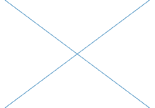

[Adding lines to figures](https://matplotlib.org/3.5.1/gallery/pyplots/fig_x.html#sphx-glr-gallery-pyplots-fig-x-py)

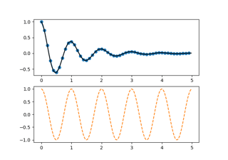

[Pyplot Two Subplots](https://matplotlib.org/3.5.1/gallery/pyplots/pyplot_two_subplots.html#sphx-glr-gallery-pyplots-pyplot-two-subplots-py)

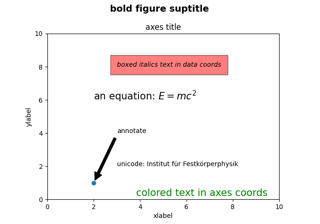

[Text Commands](https://matplotlib.org/3.5.1/gallery/pyplots/text_commands.html#sphx-glr-gallery-pyplots-text-commands-py)

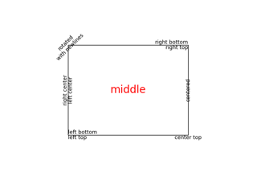

[Text Layout](https://matplotlib.org/3.5.1/gallery/pyplots/text_layout.html#sphx-glr-gallery-pyplots-text-layout-py)

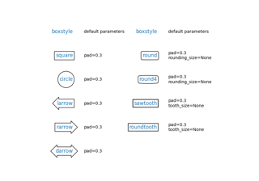

[Drawing fancy boxes](https://matplotlib.org/3.5.1/gallery/shapes_and_collections/fancybox_demo.html#sphx-glr-gallery-shapes-and-collections-fancybox-demo-py)

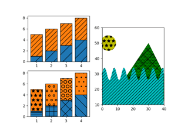

[Hatch demo](https://matplotlib.org/3.5.1/gallery/shapes_and_collections/hatch_demo.html#sphx-glr-gallery-shapes-and-collections-hatch-demo-py)

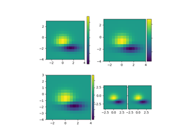

[Axes Divider](https://matplotlib.org/3.5.1/gallery/axes_grid1/demo_axes_divider.html#sphx-glr-gallery-axes-grid1-demo-axes-divider-py)

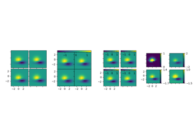

[Demo Axes Grid](https://matplotlib.org/3.5.1/gallery/axes_grid1/demo_axes_grid.html#sphx-glr-gallery-axes-grid1-demo-axes-grid-py)

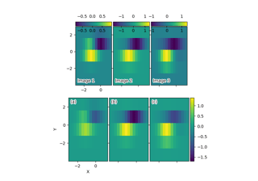

[Axes Grid2](https://matplotlib.org/3.5.1/gallery/axes_grid1/demo_axes_grid2.html#sphx-glr-gallery-axes-grid1-demo-axes-grid2-py)

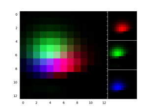

[Showing RGB channels using RGBAxes](https://matplotlib.org/3.5.1/gallery/axes_grid1/demo_axes_rgb.html#sphx-glr-gallery-axes-grid1-demo-axes-rgb-py)

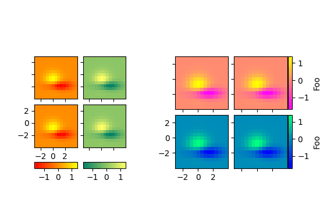

[Per-row or per-column colorbars](https://matplotlib.org/3.5.1/gallery/axes_grid1/demo_edge_colorbar.html#sphx-glr-gallery-axes-grid1-demo-edge-colorbar-py)

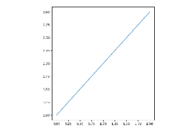

[Axes with a fixed physical size](https://matplotlib.org/3.5.1/gallery/axes_grid1/demo_fixed_size_axes.html#sphx-glr-gallery-axes-grid1-demo-fixed-size-axes-py)